```python
import pandas as pd
import matplotlib.pyplot as plt
%matplotlib inline
plt.style.use('seaborn')
from scipy.stats import norm, skew
import numpy as np
import seaborn as sns
```

# Assignment 1 - House Price Prediction

### Laurens Doedes Breuning ten Cate - MBD'18 - Machine Learning II

**kaggle score notes**

- Kaggle username: Laurenstc
- Kaggle final best score: RMSLE = 0.11459
- Kaggle final best score rank: 199

**local score notes**

Locally I managed when to obtain consistent RMSE's of below 0.10. However, this notebook does not include my best local RMSE score as this was due to a ton of overfitting.

**final delivery notes**

The experimental dataset we are going to use is the House Prices Dataset. It includes 79 explanatory variables of residential homes. For more details on the dataset and the competition see https://www.kaggle.com/c/house-prices-advanced-regression-techniques.

The workbook is structured as followed:

1. Data Cleaning and Pre-processing
   - Outliers
   - Statistical transformations
2. Feature Engineering
   - Concatenation
   - NA's
   - Incorrect values
   - Factorization
   - Further Statistical transformation
   - Column removal
   - Creating features
   - Dummies
   - In-depth outlier detection
   - Overfit prevention
   - Baseline model
3. Feature Selection
   - Filter methods
     - baseline coefficients
   - Embedded methods
     - L2: Ridge Regression
     - L1: Lasso regression
       - In-depth coefficient analysis
     - Elasticnet
4. Ensemble methods
   - Stacked generalizations
   - Averaging
     - standard
     - weighted
5. Prediction

This notebook represents the data manipulation used for my final score on Kaggle (RMSLE = 0.11459). However, in the process of achieving this score a lot of different feature engineering tactics were employed. For the sake of brevity I left these out of the notebook though below is a quick overview of other things I tried that did not help my score.

One thing that was used but was not included is GridsearchCV. Gridsearching helped me find ranges of Alphas and L1_ratios that I could reuse later. However, it became unfeasible to continuously gridserach for optimal parameters with each iteration of feature engineering. Thats why I decided to omit the code from the final delivery.

**feature engineering tries**

- Recoding categoricals to keep ordering information (if data was really ordinal)
- Binning date variables (yearbuilt etc)
- simplify and recode neighborhood variable based on a groupby with SalePrice
- create simplified quality variables (1-5 scale instead of 1-10)
- create 2nd and 3rd order polynomials of top10 strongest correlating variables with SalePrice
- create 2nd and 3rd order polynomials of all variables
- create interaction variables by looking at individual interaction plots
- use sklearns PolynomialPreprocessing for complete set of interaction and polynomial terms

**feature selection tries**

- F-score selection
- Mutual information regression selection
- Backwards stepwise selection (RFECV)
- Forwards stepwise selection (LARS)

Besides feature selection and engineering a lot of time was spent on optimizing my ensemble of models. I believe some more gains can be made here specifically regarding my stacked generalization model. I tried optimizing my hyperparameters but unfortunately after running a single gridsearch for 2 days and it still not being finished I had to abandon that project.

In the end I believe the biggest gains in my score were achieved with a few things. OLS outlier removal, nuanced NA filling and averaging with a stacked generalization model.

```python
#Data reading

train = pd.read_csv("c:/Users/Laurens/Documents/IE-BIGDATA/Term 2/Machine Learning II/lab1/train.csv")
test = pd.read_csv("c:/Users/Laurens/Documents/IE-BIGDATA/Term 2/Machine Learning II/lab1/test.csv")
```

```python
print("Train set size:", train.shape)
print("Test set size:", test.shape)
```

```
Train set size: (1460, 81)
Test set size: (1459, 80)
```

# 1. Data Cleaning and Pre-processing

## Outliers

According to the documentation of the dataset (http://ww2.amstat.org/publications/jse/v19n3/Decock/DataDocumentation.txt) there are outliers present that are recommended to be removed. Let's plot SalePrice vs GR LIV AREA to view these.

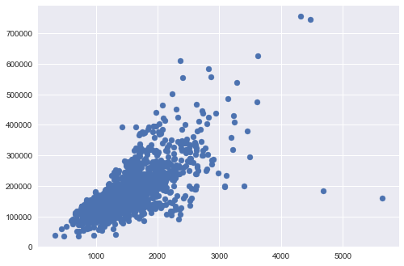

```python
plt.scatter(train.GrLivArea, train.SalePrice)
```

These outliers are extremely clear. The documentation recommends removing all houses above 4000 sq ft living area. Trial and error showed that this led to a little bit underfitting. Better performance was above 4500 sq.

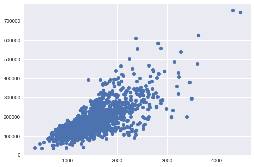

```python
train = train[train.GrLivArea < 4500]
plt.scatter(train.GrLivArea, train.SalePrice)
```

```python
print(len(np.unique(train['Id'])) == len(train))
len(np.unique(test['Id'])) == len(test)
```

```
True
```

```
True
```

```python
len(train)
```

```
1458
```

So we can safely drop the Id columns.

```python
train = train.drop(['Id'], axis=1)
test = test.drop(['Id'], axis=1)
```

```python
print("Train set size:", train.shape)
print("Test set size:", test.shape)
```

```
Train set size: (1458, 80)
Test set size: (1459, 79)
```

## Statistical transformation

Let's have a look at how the target variable is distributed.

```python
df = pd.concat([train.SalePrice, np.log(train.SalePrice + 1).rename('LogSalePrice')], axis=1, names=['SalePrice', 'LogSalePrice'])
df.head()
```

|  | SalePrice | LogSalePrice |
| --- | --- | --- |
| 0 | 208500 | 12.247699 |
| 1 | 181500 | 12.109016 |
| 2 | 223500 | 12.317171 |
| 3 | 140000 | 11.849405 |
| 4 | 250000 | 12.429220 |

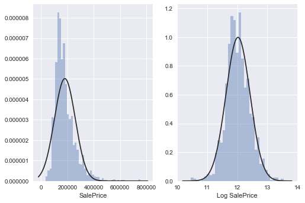

```python
plt.subplot(1, 2, 1)
sns.distplot(train.SalePrice, kde=False, fit = norm)

plt.subplot(1, 2, 2)
sns.distplot(np.log(train.SalePrice + 1), kde=False, fit = norm)
plt.xlabel('Log SalePrice')
```

There seems to be clear evidence of right-skewedness in the target variable. We can correct this with a simple log transformation.

```python
train.SalePrice = np.log1p(train.SalePrice)
```

# 2. Feature Engineering

## Concatenation

To keep consistency between test and train features we concatenate the two sets while remembering the index so we can split it later again.

```python
y = train.SalePrice.reset_index(drop=True)
train_features = train.drop(['SalePrice'], axis=1)
test_features = test
```

```python
print(train_features.shape)
print(test_features.shape)
```

```
(1458, 79)
(1459, 79)
```

```python
features = pd.concat([train_features, test_features]).reset_index(drop=True)
features.shape
```

```
(2917, 79)
```

## NA's

Let's figure out what NA's excist, sort them by categories and impute them in the best possible way.

```python
nulls = np.sum(features.isnull())
nullcols = nulls.loc[(nulls != 0)]
dtypes = features.dtypes
dtypes2 = dtypes.loc[(nulls != 0)]
info = pd.concat([nullcols, dtypes2], axis=1).sort_values(by=0, ascending=False)
print(info)
print("There are", len(nullcols), "columns with missing values")
```

```
                 0        1
PoolQC        2908   object
MiscFeature   2812   object
Alley         2719   object
Fence         2346   object
FireplaceQu   1420   object
LotFrontage    486  float64
GarageFinish   159   object
GarageQual     159   object
GarageCond     159   object
GarageYrBlt    159  float64
GarageType     157   object
BsmtExposure    82   object
BsmtCond        82   object
BsmtQual        81   object
BsmtFinType2    80   object
BsmtFinType1    79   object
MasVnrType      24   object
MasVnrArea      23  float64
MSZoning         4   object
BsmtFullBath     2  float64
BsmtHalfBath     2  float64
Functional       2   object
Utilities        2   object
GarageArea       1  float64
GarageCars       1  float64
Electrical       1   object
KitchenQual      1   object
TotalBsmtSF      1  float64
BsmtUnfSF        1  float64
BsmtFinSF2       1  float64
BsmtFinSF1       1  float64
Exterior2nd      1   object
Exterior1st      1   object
SaleType         1   object
There are 34 columns with missing values
```

Most of these can be filled with 'None'. Some exceptions though:

- Functional: The documentation says that we should assume "Typ", so lets impute that.
- Electrical: The documentation doesn't give any information but obviously every house has this so let's impute the most common value: "SBrkr".
- KitchenQual: Similar to Electrical, most common value: "TA".
- Exterior 1 and Exterior 2: Let's use the most common one here.
- SaleType: Similar to electrical, let's use most common value.

```python
features['Functional'] = features['Functional'].fillna('Typ')
features['Electrical'] = features['Electrical'].fillna("SBrkr")
features['KitchenQual'] = features['KitchenQual'].fillna("TA")

features['Exterior1st'] = features['Exterior1st'].fillna(features['Exterior1st'].mode()[0])
features['Exterior2nd'] = features['Exterior2nd'].fillna(features['Exterior2nd'].mode()[0])

features['SaleType'] = features['SaleType'].fillna(features['SaleType'].mode()[0])
```

Let's check some points individually to figure out the best imputation strategy

```python
pd.set_option('max_columns', None)
features[features['PoolArea'] > 0 & features['PoolQC'].isnull()]
```

|  | MSSubClass | MSZoning | LotFrontage | LotArea | Street | Alley | LotShape | LandContour | Utilities | LotConfig | LandSlope | Neighborhood | Condition1 | Condition2 | BldgType | HouseStyle | OverallQual | OverallCond | YearBuilt | YearRemodAdd | RoofStyle | RoofMatl | Exterior1st | Exterior2nd | MasVnrType | MasVnrArea | ExterQual | ExterCond | Foundation | … |
| --- | --- | --- | --- | --- | --- | --- | --- | --- | --- | --- | --- | --- | --- | --- | --- | --- | --- | --- | --- | --- | --- | --- | --- | --- | --- | --- | --- | --- | --- | --- |
| 197 | 75 | RL | 174.0 | 25419 | Pave | NaN | Reg | Lvl | AllPub | Corner | Gtl | NAmes | Artery | Norm | 1Fam | 2Story | 8 | 4 | 1918 | 1990 | Gable | CompShg | Stucco | Stucco | None | 0.0 | Gd | Gd | PConc | … |
| 809 | 20 | RL | 78.0 | 10140 | Pave | NaN | Reg | Lvl | AllPub | Inside | Gtl | NWAmes | Norm | Norm | 1Fam | 1Story | 6 | 6 | 1974 | 1999 | Hip | CompShg | HdBoard | HdBoard | BrkFace | 99.0 | TA | TA | CBlock | … |
| 1169 | 80 | RL | 76.0 | 9880 | Pave | NaN | Reg | Lvl | AllPub | Inside | Gtl | Mitchel | Norm | Norm | 1Fam | SLvl | 6 | 6 | 1977 | 1977 | Gable | CompShg | Plywood | Plywood | None | 0.0 | TA | TA | CBlock | … |
| 1181 | 60 | RL | 160.0 | 15623 | Pave | NaN | IR1 | Lvl | AllPub | Corner | Gtl | NoRidge | Norm | Norm | 1Fam | 2Story | 10 | 5 | 1996 | 1996 | Hip | CompShg | Wd Sdng | ImStucc | None | 0.0 | Gd | TA | PConc | … |
| 1384 | 60 | RL | 80.0 | 16692 | Pave | NaN | IR1 | Lvl | AllPub | Inside | Gtl | NWAmes | RRAn | Norm | 1Fam | 2Story | 7 | 5 | 1978 | 1978 | Gable | CompShg | Plywood | Plywood | BrkFace | 184.0 | TA | TA | CBlock | … |
| 1421 | 80 | RL | NaN | 19690 | Pave | NaN | IR1 | Lvl | AllPub | CulDSac | Gtl | Edwards | Norm | Norm | 1Fam | SLvl | 6 | 7 | 1966 | 1966 | Flat | Tar&Grv | Plywood | Plywood | None | 0.0 | Gd | Gd | CBlock | … |
| 1972 | 20 | RL | 106.0 | 12720 | Pave | NaN | Reg | HLS | AllPub | Inside | Mod | NridgHt | Norm | Norm | 1Fam | 1Story | 10 | 5 | 2003 | 2003 | Hip | CompShg | MetalSd | MetalSd | Stone | 680.0 | Ex | TA | PConc | … |
| 2418 | 20 | RL | 75.0 | 9532 | Pave | NaN | Reg | Lvl | AllPub | Inside | Gtl | NAmes | Norm | Norm | 1Fam | 1Story | 4 | 6 | 1953 | 1953 | Gable | CompShg | VinylSd | VinylSd | None | 0.0 | TA | TA | CBlock | … |
| 2501 | 50 | RL | 104.0 | 23920 | Pave | NaN | Reg | Lvl | AllPub | Inside | Gtl | SawyerW | Feedr | Norm | 1Fam | 1.5Fin | 6 | 5 | 1984 | 1984 | Gable | CompShg | Wd Sdng | Wd Sdng | None | 0.0 | TA | TA | CBlock | … |
| 2571 | 20 | RL | 70.0 | 18044 | Pave | NaN | IR1 | HLS | AllPub | CulDSac | Gtl | Crawfor | Norm | Norm | 1Fam | 1Story | 8 | 5 | 1986 | 1986 | Gable | CompShg | WdShing | Plywood | None | 0.0 | Gd | TA | CBlock | … |
| 2597 | 20 | RL | 200.0 | 43500 | Pave | NaN | Reg | Lvl | AllPub | Inside | Gtl | Mitchel | Artery | Norm | 1Fam | 1Story | 3 | 5 | 1953 | 1953 | Gable | CompShg | MetalSd | MetalSd | None | 0.0 | TA | TA | CBlock | … |
| 2708 | 80 | RL | 100.0 | 14330 | Pave | NaN | IR1 | Low | AllPub | Corner | Gtl | Veenker | Norm | Norm | 1Fam | SLvl | 7 | 4 | 1974 | 1974 | Gable | CompShg | WdShing | Wd Sdng | BrkFace | 145.0 | Gd | Fa | CBlock | … |

There are three NaN's foor PoolQC that have a PoolArea. Let's impute them based on overall quality of the house.

```python
features.loc[2418, 'PoolQC'] = 'Fa'
features.loc[2501, 'PoolQC'] = 'Gd'
features.loc[2597, 'PoolQC'] = 'Fa'
```

```python
pd.set_option('max_columns', None)
features[(features['GarageType'] == 'Detchd') & features['GarageYrBlt'].isnull()]
```

|  | MSSubClass | MSZoning | LotFrontage | LotArea | Street | Alley | LotShape | LandContour | Utilities | LotConfig | LandSlope | Neighborhood | Condition1 | Condition2 | BldgType | HouseStyle | OverallQual | OverallCond | YearBuilt | YearRemodAdd | RoofStyle | RoofMatl | Exterior1st | Exterior2nd | MasVnrType | MasVnrArea | ExterQual | ExterCond | Foundation | … |
| --- | --- | --- | --- | --- | --- | --- | --- | --- | --- | --- | --- | --- | --- | --- | --- | --- | --- | --- | --- | --- | --- | --- | --- | --- | --- | --- | --- | --- | --- | --- |
| 2124 | 60 | RM | 57.0 | 8094 | Pave | Grvl | Reg | Lvl | AllPub | Inside | Gtl | OldTown | Norm | Norm | 2fmCon | 2.5Unf | 6 | 8 | 1910 | 1983 | Gable | CompShg | Wd Sdng | Wd Sdng | None | 0.0 | TA | TA | PConc | … |
| 2574 | 70 | RM | 50.0 | 9060 | Pave | NaN | Reg | Lvl | AllPub | Inside | Gtl | IDOTRR | Norm | Norm | 1Fam | 2Story | 5 | 6 | 1923 | 1999 | Gable | CompShg | Wd Sdng | Plywood | None | 0.0 | TA | TA | BrkTil | … |

So there are houses with garages that are detached but that have NaN's for all other Garage variables. Let's impute these manually too.

```python
features.loc[2124, 'GarageYrBlt'] = features['GarageYrBlt'].median()
features.loc[2574, 'GarageYrBlt'] = features['GarageYrBlt'].median()

features.loc[2124, 'GarageFinish'] = features['GarageFinish'].mode()[0]
features.loc[2574, 'GarageFinish'] = features['GarageFinish'].mode()[0]

features.loc[2574, 'GarageCars'] = features['GarageCars'].median()

features.loc[2124, 'GarageArea'] = features['GarageArea'].median()
features.loc[2574, 'GarageArea'] = features['GarageArea'].median()

features.loc[2124, 'GarageQual'] = features['GarageQual'].mode()[0]
features.loc[2574, 'GarageQual'] = features['GarageQual'].mode()[0]

features.loc[2124, 'GarageCond'] = features['GarageCond'].mode()[0]
features.loc[2574, 'GarageCond'] = features['GarageCond'].mode()[0]
```

Let's look at the basements:

- BsmtQual
- BsmtCond
- BsmtExposure
- BsmtFinType1
- BsmtFinType2
- BsmtFinSF1
- BsmtFinSF2
- BsmtUnfSF
- TotalBsmtSF

```python
basement_columns = ['BsmtQual', 'BsmtCond', 'BsmtExposure', 'BsmtFinType1',
                   'BsmtFinType2', 'BsmtFinSF1', 'BsmtFinSF2', 'BsmtUnfSF',
                   'TotalBsmtSF']

tempdf = features[basement_columns]
tempdfnulls = tempdf[tempdf.isnull().any(axis=1)]
```

```python
#now select just the rows that have less then 5 NA's,
# meaning there is incongruency in the row.
tempdfnulls[(tempdfnulls.isnull()).sum(axis=1) < 5]
```

|  | BsmtQual | BsmtCond | BsmtExposure | BsmtFinType1 | BsmtFinType2 | BsmtFinSF1 | BsmtFinSF2 | BsmtUnfSF | TotalBsmtSF |
| --- | --- | --- | --- | --- | --- | --- | --- | --- | --- |
| 332 | Gd | TA | No | GLQ | NaN | 1124.0 | 479.0 | 1603.0 | 3206.0 |
| 947 | Gd | TA | NaN | Unf | Unf | 0.0 | 0.0 | 936.0 | 936.0 |
| 1485 | Gd | TA | NaN | Unf | Unf | 0.0 | 0.0 | 1595.0 | 1595.0 |
| 2038 | Gd | NaN | Mn | GLQ | Rec | 1044.0 | 382.0 | 0.0 | 1426.0 |
| 2183 | TA | NaN | No | BLQ | Unf | 1033.0 | 0.0 | 94.0 | 1127.0 |
| 2215 | NaN | Fa | No | Unf | Unf | 0.0 | 0.0 | 173.0 | 173.0 |
| 2216 | NaN | TA | No | Unf | Unf | 0.0 | 0.0 | 356.0 | 356.0 |
| 2346 | Gd | TA | NaN | Unf | Unf | 0.0 | 0.0 | 725.0 | 725.0 |
| 2522 | TA | NaN | Av | ALQ | Unf | 755.0 | 0.0 | 240.0 | 995.0 |

Let's impute all incongruencies with the most likely value.

```python
features.loc[332, 'BsmtFinType2'] = 'ALQ' #since smaller than SF1
features.loc[947, 'BsmtExposure'] = 'No'
features.loc[1485, 'BsmtExposure'] = 'No'
features.loc[2038, 'BsmtCond'] = 'TA'
features.loc[2183, 'BsmtCond'] = 'TA'
features.loc[2215, 'BsmtQual'] = 'Po' #v small basement so let's do Poor.
features.loc[2216, 'BsmtQual'] = 'Fa' #similar but a bit bigger.
features.loc[2346, 'BsmtExposure'] = 'No' #unfinished bsmt so prob not.
features.loc[2522, 'BsmtCond'] = 'Gd' #cause ALQ for bsmtfintype1
```

Zoning is also interesting

```python
subclass_group = features.groupby('MSSubClass')
Zoning_modes = subclass_group['MSZoning'].apply(lambda x : x.mode()[0])
Zoning_modes
```

```
MSSubClass
20     RL
30     RM
40     RL
45     RM
50     RL
60     RL
70     RM
75     RM
80     RL
85     RL
90     RL
120    RL
150    RL
160    RM
180    RM
190    RL
Name: MSZoning, dtype: object
```

```python
features['MSZoning'] = features.groupby('MSSubClass')['MSZoning'].transform(lambda x: x.fillna(x.mode()[0]))
```

For the rest we will just use a loop to impute 'None' value.

```python
objects = []
for i in features.columns:
    if features[i].dtype == object:
        objects.append(i)

features.update(features[objects].fillna('None'))

nulls = np.sum(features.isnull())
nullcols = nulls.loc[(nulls != 0)]
dtypes = features.dtypes
dtypes2 = dtypes.loc[(nulls != 0)]
info = pd.concat([nullcols, dtypes2], axis=1).sort_values(by=0, ascending=False)
print(info)
print("There are", len(nullcols), "columns with missing values")
```

```
                0        1
LotFrontage   486  float64
GarageYrBlt   157  float64
MasVnrArea     23  float64
BsmtFullBath    2  float64
BsmtHalfBath    2  float64
BsmtFinSF1      1  float64
BsmtFinSF2      1  float64
BsmtUnfSF       1  float64
TotalBsmtSF     1  float64
There are 9 columns with missing values
```

Now let's think about imputing the missing values in the numerical features. Most of the time I will impute 0, but sometimes something else is needed.

- LotFrontage: This is linear feet of street connected to property. Let's impute with the median per neighborhood since I assume this is extremely linked to what kind of area you live in.

```python
neighborhood_group = features.groupby('Neighborhood')
lot_medians = neighborhood_group['LotFrontage'].median()
lot_medians
```

```
Neighborhood
Blmngtn    43.0
Blueste    24.0
BrDale     21.0
BrkSide    51.0
ClearCr    80.5
CollgCr    70.0
Crawfor    70.0
Edwards    64.5
Gilbert    64.0
IDOTRR     60.0
MeadowV    21.0
Mitchel    74.0
NAmes      73.0
NPkVill    24.0
NWAmes     80.0
NoRidge    89.0
NridgHt    92.0
OldTown    60.0
SWISU      60.0
Sawyer     72.0
SawyerW    67.0
Somerst    72.5
StoneBr    60.0
Timber     82.0
Veenker    80.0
Name: LotFrontage, dtype: float64
```

As expected the lotfrontage averages differ a lot per neighborhood so let's impute with the median per neighborhood.

```python
features['LotFrontage'] = features.groupby('Neighborhood')['LotFrontage'].transform(lambda x: x.fillna(x.median()))
```

Let's also take a closer look at GarageYrBlt

```python
pd.set_option('max_columns', None)
features[(features['GarageYrBlt'].isnull()) & features['GarageArea'] > 0]
```

|  | MSSubClass | MSZoning | LotFrontage | LotArea | Street | Alley | LotShape | LandContour | Utilities | LotConfig | LandSlope | Neighborhood | Condition1 | Condition2 | BldgType | HouseStyle | OverallQual | OverallCond | YearBuilt | YearRemodAdd | RoofStyle | RoofMatl | Exterior1st | Exterior2nd | MasVnrType | MasVnrArea | ExterQual | ExterCond | Foundation | … |
| --- | --- | --- | --- | --- | --- | --- | --- | --- | --- | --- | --- | --- | --- | --- | --- | --- | --- | --- | --- | --- | --- | --- | --- | --- | --- | --- | --- | --- | --- | --- |

GarageYrBlt does not have any incongruencies. Let's also examine MasVnrArea.

```python
pd.set_option('max_columns', None)
features[(features['MasVnrArea'].isnull())]
```

|  | MSSubClass | MSZoning | LotFrontage | LotArea | Street | Alley | LotShape | LandContour | Utilities | LotConfig | LandSlope | Neighborhood | Condition1 | Condition2 | BldgType | HouseStyle | OverallQual | OverallCond | YearBuilt | YearRemodAdd | RoofStyle | RoofMatl | Exterior1st | Exterior2nd | MasVnrType | MasVnrArea | ExterQual | ExterCond | Foundation | … |
| --- | --- | --- | --- | --- | --- | --- | --- | --- | --- | --- | --- | --- | --- | --- | --- | --- | --- | --- | --- | --- | --- | --- | --- | --- | --- | --- | --- | --- | --- | --- |
| 234 | 60 | RL | 64.0 | 7851 | Pave | None | Reg | Lvl | AllPub | Inside | Gtl | Gilbert | Norm | Norm | 1Fam | 2Story | 6 | 5 | 2002 | 2002 | Gable | CompShg | VinylSd | VinylSd | None | NaN | Gd | TA | PConc | … |
| 528 | 20 | RL | 70.0 | 32668 | Pave | None | IR1 | Lvl | AllPub | CulDSac | Gtl | Crawfor | Norm | Norm | 1Fam | 1Story | 6 | 3 | 1957 | 1975 | Hip | CompShg | Wd Sdng | Stone | None | NaN | Gd | TA | PConc | … |
| 649 | 60 | FV | 65.0 | 8125 | Pave | None | Reg | Lvl | AllPub | Inside | Gtl | Somerst | Norm | Norm | 1Fam | 2Story | 7 | 6 | 2007 | 2007 | Gable | CompShg | CemntBd | CmentBd | None | NaN | Gd | TA | PConc | … |
| 935 | 20 | RL | 67.0 | 10083 | Pave | None | Reg | Lvl | AllPub | Inside | Gtl | SawyerW | Norm | Norm | 1Fam | 1Story | 7 | 5 | 2003 | 2003 | Gable | CompShg | VinylSd | VinylSd | None | NaN | Gd | TA | PConc | … |
| 972 | 20 | FV | 95.0 | 11639 | Pave | None | Reg | Lvl | AllPub | Corner | Gtl | Somerst | Norm | Norm | 1Fam | 1Story | 7 | 5 | 2007 | 2008 | Gable | CompShg | CemntBd | CmentBd | None | NaN | Gd | TA | PConc | … |
| 976 | 120 | FV | 35.0 | 4274 | Pave | Pave | IR1 | Lvl | AllPub | Inside | Gtl | Somerst | Norm | Norm | TwnhsE | 1Story | 7 | 5 | 2006 | 2007 | Gable | CompShg | VinylSd | VinylSd | None | NaN | Gd | TA | PConc | … |
| 1242 | 20 | RL | 107.0 | 13891 | Pave | None | Reg | Lvl | AllPub | Inside | Gtl | NridgHt | Norm | Norm | 1Fam | 1Story | 10 | 5 | 2006 | 2006 | Gable | CompShg | VinylSd | VinylSd | None | NaN | Ex | TA | PConc | … |
| 1277 | 60 | RL | 75.0 | 9473 | Pave | None | Reg | Lvl | AllPub | Inside | Gtl | CollgCr | Norm | Norm | 1Fam | 2Story | 8 | 5 | 2002 | 2002 | Gable | CompShg | VinylSd | VinylSd | None | NaN | Gd | TA | PConc | … |
| 1689 | 60 | RL | 64.0 | 12891 | Pave | None | IR1 | Lvl | AllPub | Corner | Gtl | Gilbert | Norm | Norm | 1Fam | 2Story | 8 | 5 | 2002 | 2002 | Gable | CompShg | VinylSd | VinylSd | None | NaN | Gd | TA | PConc | … |
| 1704 | 20 | FV | 90.0 | 7993 | Pave | None | IR1 | Lvl | AllPub | Inside | Gtl | Somerst | Norm | Norm | 1Fam | 1Story | 7 | 5 | 2008 | 2009 | Gable | CompShg | VinylSd | VinylSd | None | NaN | Gd | TA | PConc | … |
| 1880 | 60 | RL | 70.0 | 8749 | Pave | None | Reg | Lvl | AllPub | Inside | Gtl | CollgCr | Norm | Norm | 1Fam | 2Story | 7 | 5 | 2002 | 2002 | Gable | CompShg | VinylSd | VinylSd | None | NaN | Gd | TA | PConc | … |
| 1990 | 60 | RL | 64.0 | 7750 | Pave | None | Reg | Lvl | AllPub | Inside | Gtl | Gilbert | RRAn | Norm | 1Fam | 2Story | 7 | 5 | 2002 | 2002 | Gable | CompShg | VinylSd | VinylSd | None | NaN | Gd | TA | PConc | … |
| 2002 | 20 | RL | 87.0 | 10037 | Pave | None | Reg | Lvl | AllPub | Corner | Gtl | Somerst | Feedr | Norm | 1Fam | 1Story | 8 | 5 | 2006 | 2007 | Hip | CompShg | VinylSd | VinylSd | None | NaN | Gd | TA | PConc | … |
| 2039 | 60 | FV | 72.5 | 7500 | Pave | None | Reg | Lvl | AllPub | Inside | Gtl | Somerst | Norm | Norm | 1Fam | 2Story | 7 | 5 | 2002 | 2002 | Gable | CompShg | VinylSd | VinylSd | None | NaN | Gd | TA | PConc | … |
| 2309 | 60 | RL | 59.0 | 15810 | Pave | None | IR1 | Lvl | AllPub | Inside | Gtl | Gilbert | RRAn | Norm | 1Fam | 2Story | 6 | 5 | 2007 | 2007 | Gable | CompShg | VinylSd | VinylSd | None | NaN | Gd | TA | CBlock | … |
| 2323 | 80 | RL | 64.0 | 11950 | Pave | None | IR1 | Lvl | AllPub | Corner | Gtl | Gilbert | Norm | Norm | 1Fam | SLvl | 7 | 5 | 2003 | 2003 | Gable | CompShg | VinylSd | VinylSd | None | NaN | Gd | TA | PConc | … |
| 2338 | 20 | RL | 85.0 | 9965 | Pave | None | Reg | Lvl | AllPub | FR2 | Gtl | Somerst | Feedr | Norm | 1Fam | 1Story | 7 | 5 | 2007 | 2007 | Gable | CompShg | VinylSd | VinylSd | None | NaN | Gd | TA | PConc | … |
| 2347 | 60 | FV | 112.0 | 12217 | Pave | None | IR1 | Lvl | AllPub | Inside | Gtl | Somerst | Norm | Norm | 1Fam | 2Story | 8 | 5 | 2007 | 2007 | Hip | CompShg | WdShing | Wd Shng | None | NaN | Gd | TA | PConc | … |
| 2366 | 120 | FV | 30.0 | 5330 | Pave | Pave | IR2 | Lvl | AllPub | Inside | Gtl | Somerst | Norm | Norm | TwnhsE | 1Story | 8 | 5 | 2006 | 2007 | Gable | CompShg | VinylSd | VinylSd | None | NaN | Gd | TA | PConc | … |
| 2590 | 20 | RL | 68.0 | 8298 | Pave | None | IR1 | HLS | AllPub | Inside | Gtl | Timber | Norm | Norm | 1Fam | 1Story | 8 | 5 | 2006 | 2007 | Hip | CompShg | VinylSd | VinylSd | None | NaN | Gd | TA | PConc | … |
| 2655 | 60 | RL | 103.0 | 12867 | Pave | None | IR1 | Lvl | AllPub | Corner | Gtl | NridgHt | Norm | Norm | 1Fam | 2Story | 8 | 5 | 2005 | 2006 | Gable | CompShg | CemntBd | CmentBd | None | NaN | Gd | TA | PConc | … |
| 2684 | 20 | RL | 49.0 | 15218 | Pave | None | IR1 | Lvl | AllPub | CulDSac | Gtl | Somerst | RRAn | Norm | 1Fam | 1Story | 8 | 5 | 2006 | 2006 | Gable | CompShg | VinylSd | VinylSd | None | NaN | Gd | TA | PConc | … |
| 2860 | 20 | RL | 75.0 | 8050 | Pave | None | Reg | Lvl | AllPub | Inside | Gtl | Edwards | Norm | Norm | 1Fam | 1Story | 6 | 5 | 2002 | 2002 | Gable | CompShg | VinylSd | VinylSd | None | NaN | TA | TA | PConc | … |

No incongruencies here either. The rest can be safely imputed with 0 since this means that the property is not present in the house.

```python
#Filling in the rest of the NA's

numeric_dtypes = ['int16', 'int32', 'int64', 'float16', 'float32', 'float64']
numerics = []
for i in features.columns:
    if features[i].dtype in numeric_dtypes:
        numerics.append(i)

features.update(features[numerics].fillna(0))

nulls = np.sum(features.isnull())
nullcols = nulls.loc[(nulls != 0)]
dtypes = features.dtypes
dtypes2 = dtypes.loc[(nulls != 0)]
info = pd.concat([nullcols, dtypes2], axis=1).sort_values(by=0, ascending=False)
print(info)
print("There are", len(nullcols), "columns with missing values")
```

```
Empty DataFrame
Columns: [0, 1]
Index: []
There are 0 columns with missing values
```

## Incorrect values

Some values can be obviously wrong and this might impact our model. I used min and max values to check odd values in the data.

```python
features.describe()
```

|  | MSSubClass | LotFrontage | LotArea | OverallQual | OverallCond | YearBuilt | YearRemodAdd | MasVnrArea | BsmtFinSF1 | BsmtFinSF2 | BsmtUnfSF | TotalBsmtSF | 1stFlrSF | 2ndFlrSF | LowQualFinSF | GrLivArea | BsmtFullBath | BsmtHalfBath | FullBath | HalfBath | BedroomAbvGr | KitchenAbvGr | TotRmsAbvGrd | Fireplaces | GarageYrBlt | GarageCars | GarageArea | WoodDeckSF | OpenPorchSF | … |
| --- | --- | --- | --- | --- | --- | --- | --- | --- | --- | --- | --- | --- | --- | --- | --- | --- | --- | --- | --- | --- | --- | --- | --- | --- | --- | --- | --- | --- | --- | --- |
| count | 2917.000000 | 2917.000000 | 2917.000000 | 2917.000000 | 2917.000000 | 2917.000000 | 2917.000000 | 2917.000000 | 2917.000000 | 2917.000000 | 2917.00000 | 2917.000000 | 2917.000000 | 2917.000000 | 2917.000000 | 2917.000000 | 2917.000000 | 2917.000000 | 2917.000000 | 2917.000000 | 2917.000000 | 2917.000000 | 2917.000000 | 2917.000000 | 2917.000000 | 2917.000000 | 2917.000000 | 2917.000000 | 2917.000000 | … |
| mean | 57.135756 | 69.436064 | 10139.439150 | 6.086390 | 5.564964 | 1971.287967 | 1984.248200 | 100.931436 | 438.864930 | 49.599246 | 560.50360 | 1048.967775 | 1157.692492 | 335.861502 | 4.697635 | 1498.251628 | 0.428865 | 0.061364 | 1.567364 | 0.379842 | 2.860130 | 1.044566 | 6.448063 | 0.596160 | 1871.627014 | 1.766198 | 472.453205 | 93.629414 | 47.280082 | … |
| std | 42.532140 | 21.208242 | 7807.036512 | 1.406704 | 1.113414 | 30.286991 | 20.892257 | 178.032499 | 444.180542 | 169.232130 | 439.69883 | 429.472008 | 385.264298 | 428.119663 | 46.412570 | 496.908626 | 0.523943 | 0.245687 | 0.552465 | 0.502782 | 0.822967 | 0.214532 | 1.564281 | 0.644773 | 447.158503 | 0.761412 | 214.574064 | 126.532643 | 67.118965 | … |
| min | 20.000000 | 21.000000 | 1300.000000 | 1.000000 | 1.000000 | 1872.000000 | 1950.000000 | 0.000000 | 0.000000 | 0.000000 | 0.00000 | 0.000000 | 334.000000 | 0.000000 | 0.000000 | 334.000000 | 0.000000 | 0.000000 | 0.000000 | 0.000000 | 0.000000 | 0.000000 | 2.000000 | 0.000000 | 0.000000 | 0.000000 | 0.000000 | 0.000000 | 0.000000 | … |
| 25% | 20.000000 | 60.000000 | 7476.000000 | 5.000000 | 5.000000 | 1953.000000 | 1965.000000 | 0.000000 | 0.000000 | 0.000000 | 220.00000 | 793.000000 | 876.000000 | 0.000000 | 0.000000 | 1126.000000 | 0.000000 | 0.000000 | 1.000000 | 0.000000 | 2.000000 | 1.000000 | 5.000000 | 0.000000 | 1957.000000 | 1.000000 | 320.000000 | 0.000000 | 0.000000 | … |
| 50% | 50.000000 | 70.000000 | 9452.000000 | 6.000000 | 5.000000 | 1973.000000 | 1993.000000 | 0.000000 | 368.000000 | 0.000000 | 467.00000 | 988.000000 | 1082.000000 | 0.000000 | 0.000000 | 1444.000000 | 0.000000 | 0.000000 | 2.000000 | 0.000000 | 3.000000 | 1.000000 | 6.000000 | 1.000000 | 1977.000000 | 2.000000 | 480.000000 | 0.000000 | 26.000000 | … |
| 75% | 70.000000 | 80.000000 | 11556.000000 | 7.000000 | 6.000000 | 2001.000000 | 2004.000000 | 163.000000 | 733.000000 | 0.000000 | 804.00000 | 1302.000000 | 1384.000000 | 704.000000 | 0.000000 | 1743.000000 | 1.000000 | 0.000000 | 2.000000 | 1.000000 | 3.000000 | 1.000000 | 7.000000 | 1.000000 | 2001.000000 | 2.000000 | 576.000000 | 168.000000 | 70.000000 | … |
| max | 190.000000 | 313.000000 | 215245.000000 | 10.000000 | 9.000000 | 2010.000000 | 2010.000000 | 1600.000000 | 4010.000000 | 1526.000000 | 2336.00000 | 5095.000000 | 5095.000000 | 2065.000000 | 1064.000000 | 5095.000000 | 3.000000 | 2.000000 | 4.000000 | 2.000000 | 8.000000 | 3.000000 | 15.000000 | 4.000000 | 2207.000000 | 5.000000 | 1488.000000 | 1424.000000 | 742.000000 | … |

Looking at the min and max of each variable there are some errors in the data.

- GarageYrBlt - the max value is 2207, this is obviously wrong since the data is only until 2010.

The rest of the data looks fine. Let's inspect this row a bit more carefully and impute an approximate correct value.

```python
features[features['GarageYrBlt'] == 2207]
```

|  | MSSubClass | MSZoning | LotFrontage | LotArea | Street | Alley | LotShape | LandContour | Utilities | LotConfig | LandSlope | Neighborhood | Condition1 | Condition2 | BldgType | HouseStyle | OverallQual | OverallCond | YearBuilt | YearRemodAdd | RoofStyle | RoofMatl | Exterior1st | Exterior2nd | MasVnrType | MasVnrArea | ExterQual | ExterCond | Foundation | … |
| --- | --- | --- | --- | --- | --- | --- | --- | --- | --- | --- | --- | --- | --- | --- | --- | --- | --- | --- | --- | --- | --- | --- | --- | --- | --- | --- | --- | --- | --- | --- |
| 2590 | 20 | RL | 68.0 | 8298 | Pave | None | IR1 | HLS | AllPub | Inside | Gtl | Timber | Norm | Norm | 1Fam | 1Story | 8 | 5 | 2006 | 2007 | Hip | CompShg | VinylSd | VinylSd | None | 0.0 | Gd | TA | PConc | … |

This particular datapoint has YearBuilt in 2006 and YearRemodAdd in 2007. 2207 most likely is a data input error that should have been 2007 when the remodel happened. Let's impute 2007.

```python
features.loc[2590, 'GarageYrBlt'] = 2007
```

## Factorization

There are features that are read in as numericals but are actually objects. Let's transform them.

```python
#factors = ['MSSubClass', 'MoSold']
factors = ['MSSubClass']



for i in factors:
    features.update(features[i].astype('str'))
```

## Skew transformation features

Let's check skew in our features and transform if necessary.

```python
from scipy.stats import skew

numeric_dtypes = ['int16', 'int32', 'int64', 'float16', 'float32', 'float64']
numerics2 = []
for i in features.columns:
    if features[i].dtype in numeric_dtypes:
        numerics2.append(i)

skew_features = features[numerics2].apply(lambda x: skew(x)).sort_values(ascending=False)
skews = pd.DataFrame({'skew':skew_features})
skews
```

|  | skew |
| --- | --- |
| MiscVal | 21.939672 |
| PoolArea | 17.688664 |
| LotArea | 13.109495 |
| LowQualFinSF | 12.084539 |
| 3SsnPorch | 11.372080 |
| KitchenAbvGr | 4.300550 |
| BsmtFinSF2 | 4.144503 |
| EnclosedPorch | 4.002344 |
| ScreenPorch | 3.945101 |
| BsmtHalfBath | 3.929996 |
| MasVnrArea | 2.621719 |
| OpenPorchSF | 2.529358 |
| WoodDeckSF | 1.844792 |
| 1stFlrSF | 1.257286 |
| LotFrontage | 1.103039 |
| GrLivArea | 1.068750 |
| BsmtFinSF1 | 0.980645 |
| BsmtUnfSF | 0.919688 |
| 2ndFlrSF | 0.861556 |
| TotRmsAbvGrd | 0.749232 |
| Fireplaces | 0.725278 |
| HalfBath | 0.696666 |
| TotalBsmtSF | 0.671751 |
| BsmtFullBath | 0.622415 |
| OverallCond | 0.569314 |
| BedroomAbvGr | 0.326568 |
| GarageArea | 0.218257 |
| MoSold | 0.197345 |
| OverallQual | 0.189591 |
| FullBath | 0.165514 |
| YrSold | 0.131996 |
| GarageCars | -0.218309 |
| YearRemodAdd | -0.450134 |
| YearBuilt | -0.599194 |
| GarageYrBlt | -3.934463 |

I use the boxcox1p transformation here because I tried the log transform first but a lot of skew remained in the data. I use boxcox1p over normal boxcox because boxcox can't handle zero values.

```python
from scipy.special import boxcox1p
from scipy.stats import boxcox_normmax

high_skew = skew_features[skew_features > 0.5]
high_skew = high_skew
skew_index = high_skew.index

for i in skew_index:
    features[i]= boxcox1p(features[i], boxcox_normmax(features[i]+1))


skew_features2 = features[numerics2].apply(lambda x: skew(x)).sort_values(ascending=False)
skews2 = pd.DataFrame({'skew':skew_features2})
skews2
```

|  | skew |
| --- | --- |
| PoolArea | 15.595057 |
| 3SsnPorch | 8.862045 |
| LowQualFinSF | 8.492615 |
| MiscVal | 5.237983 |
| BsmtHalfBath | 3.779434 |
| KitchenAbvGr | 3.778336 |
| ScreenPorch | 3.152631 |
| BsmtFinSF2 | 2.578329 |
| EnclosedPorch | 2.149133 |
| MasVnrArea | 0.977618 |
| 2ndFlrSF | 0.895453 |
| WoodDeckSF | 0.785550 |
| HalfBath | 0.732625 |
| OpenPorchSF | 0.621231 |
| BsmtFullBath | 0.616643 |
| Fireplaces | 0.553135 |
| OverallCond | 0.382457 |
| BsmtFinSF1 | 0.365986 |
| BedroomAbvGr | 0.326568 |
| TotalBsmtSF | 0.297009 |
| GarageArea | 0.218257 |
| MoSold | 0.197345 |
| OverallQual | 0.189591 |
| FullBath | 0.165514 |
| YrSold | 0.131996 |
| LotFrontage | 0.059189 |
| BsmtUnfSF | 0.054195 |
| TotRmsAbvGrd | 0.047190 |
| GrLivArea | 0.008823 |
| 1stFlrSF | -0.007822 |
| LotArea | -0.138117 |
| GarageCars | -0.218309 |
| YearRemodAdd | -0.450134 |
| YearBuilt | -0.599194 |
| GarageYrBlt | -3.934463 |

## Incomplete cases

Checking to see if levels of my variables in my train and test set match and if not or if the level distribution is very low whether it should be deleted.

```python
objects3 = []
for i in features.columns:
    if features[i].dtype == object:
        objects3.append(i)
```

```python
print("Training Set incomplete cases")

sums_features = features[objects3].apply(lambda x: len(np.unique(x)))
sums_features.sort_values(ascending=False)
```

```
Training Set incomplete cases
```

```
Neighborhood     25
MSSubClass       16
Exterior2nd      16
Exterior1st      15
Condition1        9
SaleType          9
Condition2        8
HouseStyle        8
RoofMatl          7
GarageType        7
Functional        7
BsmtFinType1      7
BsmtFinType2      7
Heating           6
RoofStyle         6
BsmtQual          6
SaleCondition     6
Foundation        6
FireplaceQu       6
GarageCond        6
GarageQual        6
MSZoning          5
LotConfig         5
MiscFeature       5
Fence             5
BldgType          5
HeatingQC         5
BsmtExposure      5
ExterCond         5
Electrical        5
BsmtCond          5
GarageFinish      4
LotShape          4
ExterQual         4
PoolQC            4
KitchenQual       4
MasVnrType        4
LandContour       4
Alley             3
LandSlope         3
Utilities         3
PavedDrive        3
Street            2
CentralAir        2
dtype: int64
```

Let's take a closer look at some of these lower numbered variables.

```python
print(features['Street'].value_counts())
print('-----')
print(features['Utilities'].value_counts())
print('-----')
print(features['CentralAir'].value_counts())
print('-----')
print(features['PavedDrive'].value_counts())
```

```
Pave    2905
Grvl      12
Name: Street, dtype: int64
-----
AllPub    2914
None         2
NoSeWa       1
Name: Utilities, dtype: int64
-----
Y    2721
N     196
Name: CentralAir, dtype: int64
-----
Y    2639
N     216
P      62
Name: PavedDrive, dtype: int64
```

I experimented a bunch with this and decided in the end that if a column has low amount of levels and most values are in the same class (>97%) I'd remove them.

Let's delete Utilities because of how unbalanced it is.

```python
#features = features.drop(['Utilities'], axis=1)
features = features.drop(['Utilities', 'Street'], axis=1)
```

## Creating features

In this section I create some features that can be created from the current data.

Size of the house. There are a few variables dealing with square footage, I don't use TotalBsmtSF as a proxy for the basement because I believe unfinished square feet in the basement area won't have a big impact on price as it needs money to make it 'livable' square footage, so I just use BsmtSF1 and BsmtSF2.

- BsmtFinSF1
- BsmtFinSF2
- 1stFlrSF
- 2ndFlrSF

Another combined variable is the bathrooms in the house. I count fullbath for 1 and halfbath for 0.5.

- FullBath
- HalfBath
- BsmtFullBath
- BsmtHalfBath

Another combined variable is the total porch size.

- OpenPorchSF
- EnclosedPorch
- 3SsnPorch
- Screenporch
- WoodDeckSF

Next to that I make some simplified features.

- haspool
- has2ndfloor
- hasgarage
- hasbsmt
- hasfireplace

```python
features['Total_sqr_footage'] = (features['BsmtFinSF1'] + features['BsmtFinSF2'] +
                                 features['1stFlrSF'] + features['2ndFlrSF'])

features['Total_Bathrooms'] = (features['FullBath'] + (0.5*features['HalfBath']) +
                               features['BsmtFullBath'] + (0.5*features['BsmtHalfBath']))

features['Total_porch_sf'] = (features['OpenPorchSF'] + features['3SsnPorch'] +
                              features['EnclosedPorch'] + features['ScreenPorch'] +
                             features['WoodDeckSF'])


#simplified features
features['haspool'] = features['PoolArea'].apply(lambda x: 1 if x > 0 else 0)
features['has2ndfloor'] = features['2ndFlrSF'].apply(lambda x: 1 if x > 0 else 0)
features['hasgarage'] = features['GarageArea'].apply(lambda x: 1 if x > 0 else 0)
features['hasbsmt'] = features['TotalBsmtSF'].apply(lambda x: 1 if x > 0 else 0)
features['hasfireplace'] = features['Fireplaces'].apply(lambda x: 1 if x > 0 else 0)
```

## Creating Dummies

Since sklearn lm.fit() does not accept strings we have to convert our objects to dummy variables.

```python
features.shape
```

```
(2917, 85)
```

```python
final_features = pd.get_dummies(features).reset_index(drop=True)
final_features.shape
```

```
(2917, 321)
```

Now we resplit the model in test and train

```python
y.shape
```

```
(1458,)
```

```python
X = final_features.iloc[:len(y),:]
testing_features = final_features.iloc[len(X):,:]

print(X.shape)
print(testing_features.shape)
```

```
(1458, 321)
(1459, 321)
```

## Overfitting prevention

### Outliers

Let's do a little bit more in-depth and rigorous analysis first on outliers. I'll employ Leave-One-Out methodology with OLS to find which points have a significant effect on our model fit.

```python
import statsmodels.api as sm

ols = sm.OLS(endog = y, exog = X)

fit = ols.fit()
test2 = fit.outlier_test()['bonf(p)']
```

```python
outliers = list(test2[test2<1e-3].index)

outliers

#print(test[test<1e-3])
```

```
[30, 88, 185, 462, 631, 967, 1322, 1451]
```

So we find that these are outliers. Let's delete these.

```python
X = X.drop(X.index[outliers])
y = y.drop(y.index[outliers])
```

### Dummy levels

```python
overfit = []
for i in X.columns:
    counts = X[i].value_counts()
    zeros = counts.iloc[0]
    if zeros / len(X) * 100 >99.94:
        overfit.append(i)
```

```python
overfit = list(overfit)
overfit
```

```
['MSSubClass_150', 'BsmtQual_Po']
```

Let's drop these from 'X' and 'testing_features'. Let's also drop MSZoning_C (all). It has about 99.44% zeros but unlike others with that kind of percentage it's being included in my lasso/ridge/elasticnet models with quite strong coefficient sizes.

```python
overfit.append('MSZoning_C (all)')
```

```python
overfit
```

```
['MSSubClass_150', 'BsmtQual_Po', 'MSZoning_C (all)']
```

```python
X.drop(overfit,axis=1,inplace=True)
testing_features.drop(overfit,axis=1,inplace=True)
```

```python
print(X.shape)
print(testing_features.shape)
```

```
(1450, 318)
(1459, 318)
```

## Baseline model

### Full Model w/ kfold cross validation

Let's build a baseline linear regression model to benchmark our feature selected models and advanced models on.

I decided not to do a manual train/test split but instead rely completely on 10-fold cross-validation for every model including our benchmark.

Our in-class benchmark has an RMSE of ~0.14 which is the goal to beat but I will rebuild a benchmark model in this notebook too.

```python
from sklearn.linear_model import LinearRegression
from sklearn.model_selection import KFold, cross_val_score
from sklearn.model_selection import cross_val_predict
from sklearn.preprocessing import RobustScaler
from sklearn.pipeline import make_pipeline

#Build our model method
lm = LinearRegression()

#Build our cross validation method
kfolds = KFold(n_splits=10, shuffle=True, random_state=23)

#build our model scoring function
def cv_rmse(model):
    rmse = np.sqrt(-cross_val_score(model, X, y,
                                   scoring="neg_mean_squared_error",
                                   cv = kfolds))
    return(rmse)


#second scoring metric
def cv_rmsle(model):
    rmsle = np.sqrt(np.log(-cross_val_score(model, X, y,
                                           scoring = 'neg_mean_squared_error',
                                           cv=kfolds)))
    return(rmsle)
```

Let's fit our first model

```python
benchmark_model = make_pipeline(RobustScaler(),
                                lm).fit(X=X, y=y)
cv_rmse(benchmark_model).mean()
```

```
38588838.656073436
```

### Visualizing baseline model

Let's see how the residuals and predictions vs actual values are distributed. Here I should note this looks absolutely ridiculous for a reason I can't figure out yet. Basically, for some reason, my baseline model gives an incredibly high residual error. I believe this is due to the fact that the dimensionality of my model is crazy high compared to the amount of data (~1500 rows vs ~320 columns). This gets reduced down with feature selection but the baseline model includes all which leads to a ton of multicollinearity causing high RMSE values.

```python
preds1 = cross_val_predict(benchmark_model, X, y, cv=kfolds)
```

```
Baseline linear model RMSE =  0.138971568973
```

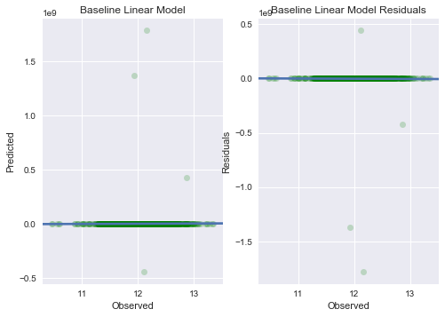

```python
from sklearn.metrics import mean_squared_error

plt.subplot(1, 2, 1)
sns.regplot(y, preds1, scatter_kws=dict(color='green', alpha=0.2))
plt.title("Baseline Linear Model")
plt.xlabel("Observed")
plt.ylabel("Predicted")
print("Baseline linear model RMSE = ", baseline_RMSE)

plt.subplot(1, 2, 2)
sns.regplot(y, y-preds1, scatter_kws=dict(color='green', alpha=0.2))
plt.title("Baseline Linear Model Residuals")
plt.xlabel("Observed")
plt.ylabel("Residuals")
```

# 3. Feature Selection

Before starting this section it should be noted that I will try to be extra careful not to create contamination during feature selection. Meaning that I will select features constrained per fold in my cross-validation to ensure no data leakage happens.

## Filter methods

### Coefficient importance

```python
coeffs = pd.DataFrame(list(zip(X.columns, benchmark_model.steps[1][1].coef_)), columns=['Predictors', 'Coefficients'])

coeffs.sort_values(by='Coefficients', ascending=False)
```

|  | Predictors | Coefficients |
| --- | --- | --- |
| 11 | 1stFlrSF | 1.680465e+08 |
| 12 | 2ndFlrSF | 1.680465e+08 |
| 7 | BsmtFinSF1 | 1.680465e+08 |
| 8 | BsmtFinSF2 | 1.680465e+08 |
| 17 | FullBath | 1.958283e+06 |
| 15 | BsmtFullBath | 1.958283e+06 |
| 37 | Total_porch_sf | 1.049932e+06 |
| 18 | HalfBath | 9.791417e+05 |
| 16 | BsmtHalfBath | 9.791417e+05 |
| 41 | hasbsmt | 4.003698e+05 |
| 66 | LotShape_IR2 | 3.914821e+05 |
| 67 | LotShape_IR3 | 3.914821e+05 |
| 68 | LotShape_Reg | 3.914821e+05 |
| 65 | LotShape_IR1 | 3.914821e+05 |
| 64 | Alley_Pave | 2.272905e+05 |
| 63 | Alley_None | 2.272904e+05 |
| 62 | Alley_Grvl | 2.272904e+05 |
| 45 | MSSubClass_180 | 1.093564e+05 |
| 43 | MSSubClass_120 | 1.093564e+05 |
| 53 | MSSubClass_70 | 1.093564e+05 |
| 56 | MSSubClass_85 | 1.093564e+05 |
| 47 | MSSubClass_20 | 1.093564e+05 |
| 46 | MSSubClass_190 | 1.093564e+05 |
| 55 | MSSubClass_80 | 1.093563e+05 |
| 51 | MSSubClass_50 | 1.093563e+05 |
| 49 | MSSubClass_40 | 1.093563e+05 |
| 52 | MSSubClass_60 | 1.093563e+05 |
| 48 | MSSubClass_30 | 1.093563e+05 |
| 44 | MSSubClass_160 | 1.093563e+05 |
| 54 | MSSubClass_75 | 1.093563e+05 |

[output cut: 171 more lines]

317 rows × 2 columns

## Embedded methods

### Ridge Regression (L2 penalty)

```python
from sklearn.linear_model import RidgeCV
from sklearn.preprocessing import PolynomialFeatures

def ridge_selector(k):
    ridge_model = make_pipeline(RobustScaler(),
                                RidgeCV(alphas = [k],
                                        cv=kfolds)).fit(X, y)

    ridge_rmse = cv_rmse(ridge_model).mean()
    return(ridge_rmse)
```

```python
r_alphas = [.0001, .0003, .0005, .0007, .0009,
          .01, 0.05, 0.1, 0.3, 1, 3, 5, 10, 15, 20, 30, 50, 60, 70, 80]

ridge_scores = []
for alpha in r_alphas:
    score = ridge_selector(alpha)
    ridge_scores.append(score)
```

|  | RMSE |
| --- | --- |
| 0.0001 | 0.121325 |
| 0.0003 | 0.116671 |
| 0.0005 | 0.114255 |
| 0.0007 | 0.112663 |
| 0.0009 | 0.111543 |
| 0.0100 | 0.107054 |
| 0.0500 | 0.106083 |
| 0.1000 | 0.105291 |
| 0.3000 | 0.103558 |
| 1.0000 | 0.101593 |
| 3.0000 | 0.100193 |
| 5.0000 | 0.099649 |
| 10.0000 | 0.099108 |
| 15.0000 | 0.099004 |
| 20.0000 | 0.099079 |
| 30.0000 | 0.099462 |
| 50.0000 | 0.100544 |
| 60.0000 | 0.101130 |
| 70.0000 | 0.101720 |
| 80.0000 | 0.102307 |

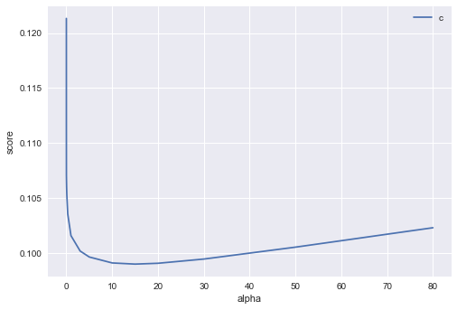

```python
plt.plot(r_alphas, ridge_scores, label='Ridge')
plt.legend('center')
plt.xlabel('alpha')
plt.ylabel('score')

ridge_score_table = pd.DataFrame(ridge_scores, r_alphas, columns=['RMSE'])
ridge_score_table
```

```python
alphas_alt = [14.5, 14.6, 14.7, 14.8, 14.9, 15, 15.1, 15.2, 15.3, 15.4, 15.5]

ridge_model2 = make_pipeline(RobustScaler(),
                            RidgeCV(alphas = alphas_alt,
                                    cv=kfolds)).fit(X, y)

cv_rmse(ridge_model2).mean()
```

```
0.099002617579982119
```

```python
ridge_model2.steps[1][1].alpha_
```

```
14.6
```

### Lasso Regression (L1 penalty)

```python
from sklearn.linear_model import LassoCV


alphas = [0.00005, 0.0001, 0.0003, 0.0005, 0.0007,
          0.0009, 0.01]
alphas2 = [0.00005, 0.0001, 0.0002, 0.0003, 0.0004, 0.0005,
           0.0006, 0.0007, 0.0008]


lasso_model2 = make_pipeline(RobustScaler(),
                             LassoCV(max_iter=1e7,
                                    alphas = alphas2,
                                    random_state = 42)).fit(X, y)
```

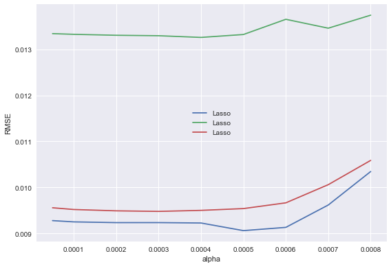

```python
scores = lasso_model2.steps[1][1].mse_path_

plt.plot(alphas2, scores, label='Lasso')
plt.legend(loc='center')
plt.xlabel('alpha')
plt.ylabel('RMSE')
plt.tight_layout()
plt.show()
```

```python
lasso_model2.steps[1][1].alpha_
```

```
0.00029999999999999997
```

```python
cv_rmse(lasso_model2).mean()
```

```
0.098868702323000601
```

```python
coeffs = pd.DataFrame(list(zip(X.columns, lasso_model2.steps[1][1].coef_)), columns=['Predictors', 'Coefficients'])
```

```python
used_coeffs = coeffs[coeffs['Coefficients'] != 0].sort_values(by='Coefficients', ascending=False)
print(used_coeffs.shape)
print(used_coeffs)
```

```
(136, 2)
                Predictors  Coefficients
60             MSZoning_RL  1.045360e-01
103   Neighborhood_StoneBr  9.968424e-02
87    Neighborhood_Crawfor  9.791366e-02
35       Total_sqr_footage  9.775687e-02
4                YearBuilt  9.722137e-02
2              OverallQual  9.469692e-02
58             MSZoning_FV  9.442058e-02
14               GrLivArea  9.154070e-02
59             MSZoning_RH  8.682235e-02
152    Exterior1st_BrkFace  8.103124e-02
256         Functional_Typ  7.983116e-02
10             TotalBsmtSF  6.944363e-02
61             MSZoning_RM  6.836377e-02
```

[output cut: 123 more lines]

```python
used_coeffs_values = X[used_coeffs['Predictors']]
used_coeffs_values.shape
```

```
(1450, 136)
```

```python
overfit_test2 = []
for i in used_coeffs_values.columns:
    counts2 = used_coeffs_values[i].value_counts()
    zeros2 = counts2.iloc[0]
    if zeros2 / len(used_coeffs_values) * 100 > 99.5:
        overfit_test2.append(i)

overfit_test2
```

```
['PoolArea', 'GarageType_2Types', 'Functional_Maj2']
```

### Elastic Net (L1 and L2 penalty)

One of the issues with Lasso is that it's likely to pick, from correlated features, one at random. Elastic net would pick both. Its a bit of a mix between ridge and lasso. I decided to include it since R's implementation of ridge regression actually invovles some elasticNet properties.

```python
from sklearn.linear_model import ElasticNetCV

e_alphas = [0.0001, 0.0002, 0.0003, 0.0004, 0.0005, 0.0006, 0.0007]
e_l1ratio = [0.8, 0.85, 0.9, 0.95, 0.99, 1]

elastic_cv = make_pipeline(RobustScaler(),
                           ElasticNetCV(max_iter=1e7, alphas=e_alphas,
                                        cv=kfolds, l1_ratio=e_l1ratio))

elastic_model3 = elastic_cv.fit(X, y)
```

```python
cv_rmse(elastic_model3).mean()
```

```
0.099168919302589059
```

```python
print(elastic_model3.steps[1][1].l1_ratio_)
print(elastic_model3.steps[1][1].alpha_)
```

```
0.85
0.0002
```

## Ensemble methods

Let's see if I can get a better performance on the test data by employing ensemble methods. To stay in the constraints of the exercise I won't employ stronger models but instead combine three models.

- LassoCV
- RidgeCV
- Elasticnet

Experimenting with averaging cost a lot of time since local RMSE and kaggle RMSLE are disconnected at this point. Basically I am optimizing the tradeoff between under and over fitting.

First I'll build a meta-regressor through a process called stacking generalizations which trains a model on a part of the training set (it gets split first into a new training set and a holdout set). Then the algorithm test these models on the holdout set and uses these predictions (called out-of-fold predictions) as input for the 'meta model'. Below is a grahpical representation of the process.

```python
from IPython.display import Image
from IPython.core.display import HTML
Image(url = "http://i.imgur.com/QBuDOjs.jpg")
```

[figure not shown]

### Ensemble 1 - Stacking Generalization

To try to eek out more performance of our already decent rank let's try Stacking Generalization, I tried a few different options. Vecstack package from python seemed to be implementing it incorrectly, so instead I decided to use the mlxtend package.

```python
from mlxtend.regressor import StackingCVRegressor

#setup models
ridge = make_pipeline(RobustScaler(),
                      RidgeCV(alphas = alphas_alt, cv=kfolds))

lasso = make_pipeline(RobustScaler(),
                      LassoCV(max_iter=1e7, alphas = alphas2,
                              random_state = 42, cv=kfolds))

elasticnet = make_pipeline(RobustScaler(),
                           ElasticNetCV(max_iter=1e7, alphas=e_alphas,
                                        cv=kfolds, l1_ratio=e_l1ratio))


#stack
stack_gen = StackingCVRegressor(regressors=(ridge, lasso, elasticnet),
                               meta_regressor=elasticnet,
                               use_features_in_secondary=True)

#prepare dataframes
stackX = np.array(X)
stacky = np.array(y)
```

```python
#scoring

print("cross validated scores")

for model, label in zip([ridge, lasso, elasticnet, stack_gen],
                     ['RidgeCV', 'LassoCV', 'ElasticNetCV',
                      'StackingCVRegressor']):

    SG_scores = cross_val_score(model, stackX, stacky, cv=kfolds,
                               scoring='neg_mean_squared_error')
    print("RMSE", np.sqrt(-SG_scores.mean()), "SD", scores.std(), label)
```

```
cross validated scores
RMSE 0.100135873151 SD 0.00186626182416 RidgeCV
RMSE 0.0998860855849 SD 0.00186626182416 LassoCV
RMSE 0.10011585254 SD 0.00186626182416 ElasticNetCV
RMSE 0.099569703441 SD 0.00186626182416 StackingCVRegressor
```

```python
stack_gen_model = stack_gen.fit(stackX, stacky)
```

### Averaging

Let's build some averages to reduce potential overfitting. This drastically helped my kaggle score. I experimented with a bunch of different weights and combination of averaging (this is mostly why my submission rate is high) since it's basically impossible to use local score at this point to optimize anything.

```python
em_preds = elastic_model3.predict(testing_features)
lasso_preds = lasso_model2.predict(testing_features)
ridge_preds = ridge_model2.predict(testing_features)
stack_gen_preds = stack_gen_model.predict(testing_features)
```

```python
stack_preds = ((0.3*em_preds) + (0.2*lasso_preds) +
               (0.2*stack_gen_preds) + (0.3*ridge_preds))
```

## Actual predictions for Kaggle

Our local highest score is 0.09 RMSE, let's see if this is overfitted or not by making actual predictions. I also transform the predictions back to normal values because the model is trained with logSalePrice

```python
submission = pd.read_csv("sample_submission.csv")
```

```python
submission.iloc[:,1] = np.expm1(stack_preds)
```

```python
submission.to_csv("Kaggle_submission_Laurens_ten_cate.csv", index=False)
```